# Import MNIST

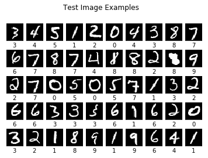

```python
import time
import io
import matplotlib.pyplot as plt
import numpy as np
from scipy.io.arff import loadarff

from sklearn.datasets import get_data_home
from sklearn.externals.joblib import Memory
from sklearn.neighbors import KNeighborsClassifier
from sklearn.model_selection import train_test_split
from sklearn.preprocessing import StandardScaler
from sklearn.utils import check_random_state
from urllib.request import urlopen

#2.  read the NMIST dataset
memory = Memory(get_data_home())
@memory.cache()
def fetch_mnist():
    content = urlopen(
        'https://www.openml.org/data/download/52667/mnist_784.arff').read()
    data, meta = loadarff(io.StringIO(content.decode('utf8')))
    data = data.view([('pixels', '<f8', 784), ('class', '|S1')])
    return data['pixels'], data['class']
X, y = fetch_mnist()

# rescale the data, use the traditional train/test split

X = X / 255.

X_train, X_test = X[:25000], X[25000:26500]
y_train, y_test = y[:25000], y[25000:26500]

### Display training images

for i in range(50):
    l1_plot = plt.subplot(5, 10, i + 1)
    l1_plot.imshow(255 * X_test[i].reshape(28, 28), interpolation='nearest',
                   cmap=plt.cm.gray)
    l1_plot.set_xticks(())
    l1_plot.set_yticks(())
    l1_plot.set_xlabel('%i' % int(y_test[i]))
plt.suptitle('Test Image Examples')
plt.show()

scaler = StandardScaler()
X_train = scaler.fit_transform(X_train)
X_test = scaler.transform(X_test)
```

# Import Own Dataset

```python
""" Custom datatset loader
    based on https://github.com/utkuozbulak/pytorch-custom-dataset-examples
"""
import pandas as pd
import imageio

class SimpleDataset():
    def __init__(self, data_path, csv_name, transform = None ):
        """
        Args:
            data_path (string): path to the folder where images and csv files are located
            csv_name (string): name of the csv lablel file
            transform: pytorch transforms for transforms and tensor conversion
        """
        # Set path
        self.data_path = data_path
        # Read the csv file
        self.data_info = pd.read_csv(data_path + csv_name, header=None)
        # First column contains the image paths
        self.image_arr = np.asarray(self.data_info.iloc[:, 0])
        # Second column is the labels
        self.label_arr = np.asarray(self.data_info.iloc[:, 1])
        # Calculate len
        self.data_len = len(self.data_info.index)

    def __getitem__(self, index):
        # Get image name from the pandas df
        single_image_name = self.image_arr[index]
        # Open image
        img_as_img = imageio.imread(self.data_path + single_image_name)

        # Get label(class) of the image based on the cropped pandas column
        single_image_label = self.label_arr[index]

        return (img_as_img, single_image_label)

    def __len__(self):
        return self.data_len

mydata = SimpleDataset( "./idata/", "labels.csv")

#splitting into images and labels
X_own = []
y_own = []
for i in range(len(mydata)):
    X_own.append(mydata[i][0])
    y_own.append(mydata[i][1])

#converting into numpy arrays to enable easy reshaping and other array operations

X_own = np.asarray(X_own)
print("Shape of the input image", X_own.shape)
y_own= np.asarray(y_own)
y_own=y_own.astype('|S1')

X_own = X_own.reshape(X_own.shape[0], 784)
X_own = X_own / 255.
#data standardiation with the training set statistics is required for this clasifier
X_own = scaler.fit_transform(X_own)
```

```
Shape of the input image (60, 28, 28)
```

# KNN 1 Near Neighbor on MNIST

```python
start_time = time.time()
#Classifier Declaration
KNN1 = KNeighborsClassifier(n_neighbors=1)
#Train the classifier
KNN1.fit(X,y)
train_time = time.time() - start_time
start_time = time.time()
print("Training time %.3f seconds" % train_time)
#Evaluate the result
score = KNN1.score(X_test,y_test)
test_time = time.time() - start_time
print("Test time %.3f seconds" % test_time)
print("Test score with 1NN is: %.4f" % score)
```

```
Training time 35.211 seconds
Test time 456.786 seconds
Test score with 1NN is: 1.0000
```

# KNN 1 Near Neighbor on Own Dataset

```python
start_time = time.time()
#Evaluate the result
score = KNN1.score(X_own,y_own)
test_time = time.time() - start_time
print("Test time %.3f seconds" % test_time)
print("Test score with 1NN is: %.4f" % score)
```

[output not shown]

# KNN 3 Near Neighbor on MNIST

```python
start_time = time.time()
#Classifier Declaration
KNN3 = KNeighborsClassifier(n_neighbors=3)
#Train the classifier
KNN3.fit(X,y)
train_time = time.time() - start_time
start_time = time.time()
print("Training time %.3f seconds" % train_time)
#Evaluate the result
score = KNN3.score(X_test,y_test)
test_time = time.time() - start_time
print("Test time %.3f seconds" % test_time)
print("Test score with 3NN is: %.4f" % score)
```

```
Training time 21.330 seconds
Test time 215.089 seconds
Test score with 3NN is: 0.9727
```

# KNN 3 Near Neighbor on Own Dataset

```python
start_time = time.time()
#Evaluate the result
score = KNN3.score(X_own,y_own)
test_time = time.time() - start_time
print("Test time %.3f seconds" % test_time)
print("Test score with 3NN is: %.4f" % score)
```

```
Test time 7.496 seconds
Test score with 3NN is: 0.7167
```

# KNN 7 Near Neighbor on MNIST

```python
start_time = time.time()
#Classifier Declaration
KNN7 = KNeighborsClassifier(n_neighbors=7)
#Train the classifier
KNN7.fit(X,y)
train_time = time.time() - start_time
start_time = time.time()
print("Training time %.3f seconds" % train_time)
#Evaluate the result
score = KNN7.score(X_test,y_test)
test_time = time.time() - start_time
print("Test time %.3f seconds" % test_time)
print("Test score with 7NN is: %.4f" % score)
```

```
Training time 20.500 seconds
Test time 216.328 seconds
Test score with 7NN is: 0.9560
```

# KNN 7 Near Neighbor on Own Dataset

```python
start_time = time.time()
#Evaluate the result
score = KNN7.score(X_own,y_own)
test_time = time.time() - start_time
print("Test time %.3f seconds" % test_time)
print("Test score with 7NN is: %.4f" % score)
```

```
Test time 7.379 seconds
Test score with 7NN is: 0.7167
```

# KNN Observations

The K Nearest Neighbor algorithm is a supervised learning algorithm useful in both classifier and regression type of problems. It is expected that as K increases, the predictions become more stable. However, 'stable' does not indicate accuracy as evident from the exercise. The highest scores were obtained for K=1. The KNN algorithm becomes significantly slower as the number of training and testing entries increases.

Another interesting observation is the split between training time and testing time. In general, we would like any classifier to take more time to train and less time to test so that in the real world, we could deploy a pre-trained model which makes quick predictions. KNN, however, takes less time to train and significanty more time to make predictions. This is because in the training step, KNN simply memorizes all the data available. The actual computaions take place in the testing stage.

# MULTILAYER PERCEPTRON CLASSIFIER

# Reload MNIST

```python
import io
from scipy.io.arff import loadarff
import matplotlib.pyplot as plt
import numpy as np
from sklearn.datasets import get_data_home
from sklearn.externals.joblib import Memory
from sklearn.neural_network import MLPClassifier
from sklearn.preprocessing import StandardScaler
try:
    from urllib.request import urlopen
except ImportError:
    # Python 2
    from urllib2 import urlopen

print(__doc__)

memory = Memory(get_data_home())


@memory.cache()
def fetch_mnist():
    content = urlopen(
        'https://www.openml.org/data/download/52667/mnist_784.arff').read()
    data, meta = loadarff(io.StringIO(content.decode('utf8')))
    data = data.view([('pixels', '<f8', 784), ('class', '|S1')])
    return data['pixels'], data['class']

X, y = fetch_mnist()
# rescale the data, use the traditional train/test split
X_train, X_test = X[:60000], X[60000:]
y_train, y_test = y[:60000], y[60000:]
```

```
 Custom datatset loader
    based on https://github.com/utkuozbulak/pytorch-custom-dataset-examples
```

# Single Hidden Layer

```
Iteration 1, loss = 1.74118271
Iteration 2, loss = 0.64862143
Iteration 3, loss = 0.49210061
Iteration 4, loss = 0.41045679
Iteration 5, loss = 0.36014962
Iteration 6, loss = 0.32418903
Iteration 7, loss = 0.29745525
Iteration 8, loss = 0.27571831
Iteration 9, loss = 0.25829411
Iteration 10, loss = 0.24301983
Iteration 11, loss = 0.23038066
Iteration 12, loss = 0.22051276
Iteration 13, loss = 0.21199458
Iteration 14, loss = 0.20397429
Iteration 15, loss = 0.19728220
Iteration 16, loss = 0.19052853
Iteration 17, loss = 0.18529575
Iteration 18, loss = 0.18051926
Iteration 19, loss = 0.17520329
Iteration 20, loss = 0.17121235
Iteration 21, loss = 0.16598587
Iteration 22, loss = 0.16347922
Iteration 23, loss = 0.15926564
Iteration 24, loss = 0.15588583
Iteration 25, loss = 0.15303965
```

```
Training set score: 0.956867
```

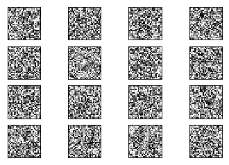

```python
# Single hidden layer
mlp = MLPClassifier(hidden_layer_sizes=(100,), max_iter=25, alpha=1e-4,
                    solver='sgd', verbose=10, tol=1e-4, random_state=1,
                    learning_rate_init=.0002)

mlp.fit(X_train, y_train)
print("Training set score: %f" % mlp.score(X_train, y_train))

fig, axes = plt.subplots(4, 4)
# use global min / max to ensure all weights are shown on the same scale
vmin, vmax = mlp.coefs_[0].min(), mlp.coefs_[0].max()
for coef, ax in zip(mlp.coefs_[0].T, axes.ravel()):
    ax.matshow(coef.reshape(28, 28), cmap=plt.cm.gray, vmin=.5 * vmin,
               vmax=.5 * vmax)
    ax.set_xticks(())
    ax.set_yticks(())

plt.show()
```

# MNIST

```python
print("MNIST test set score: %f" % mlp.score(X_test, y_test))
```

```
MNIST test set score: 0.934300
```

# Own Dataset

```python
print("Own test set score: %f" % mlp.score(X_own, y_own))
```

```
Own test set score: 0.466667
```

# Two Hidden Layers

```
Iteration 1, loss = 1.83147328
Iteration 2, loss = 0.51815980
Iteration 3, loss = 0.38678517
Iteration 4, loss = 0.32553808
Iteration 5, loss = 0.28501030
Iteration 6, loss = 0.25863211
Iteration 7, loss = 0.23686058
Iteration 8, loss = 0.22088664
Iteration 9, loss = 0.20659613
Iteration 10, loss = 0.19510804
Iteration 11, loss = 0.18568715
Iteration 12, loss = 0.17613444
Iteration 13, loss = 0.16829610
Iteration 14, loss = 0.16176363
Iteration 15, loss = 0.15527347
Iteration 16, loss = 0.14977611
Iteration 17, loss = 0.14453175
Iteration 18, loss = 0.14012680
Iteration 19, loss = 0.13592250
Iteration 20, loss = 0.13135334
Iteration 21, loss = 0.12805194
Iteration 22, loss = 0.12422220
Iteration 23, loss = 0.12147775
Iteration 24, loss = 0.11867670
Iteration 25, loss = 0.11543761
```

```
Training set score: 0.967233
```

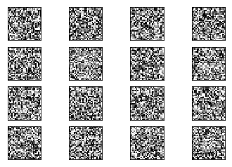

```python
# Single hidden layer
mlp = MLPClassifier(hidden_layer_sizes=(100,100), max_iter=25, alpha=1e-4,
                    solver='sgd', verbose=10, tol=1e-4, random_state=1,
                    learning_rate_init=.0002)

mlp.fit(X_train, y_train)
print("Training set score: %f" % mlp.score(X_train, y_train))

fig, axes = plt.subplots(4, 4)
# use global min / max to ensure all weights are shown on the same scale
vmin, vmax = mlp.coefs_[0].min(), mlp.coefs_[0].max()
for coef, ax in zip(mlp.coefs_[0].T, axes.ravel()):
    ax.matshow(coef.reshape(28, 28), cmap=plt.cm.gray, vmin=.5 * vmin,
               vmax=.5 * vmax)
    ax.set_xticks(())
    ax.set_yticks(())

plt.show()
```

# MNIST

```python
print("MNIST test set score: %f" % mlp.score(X_test, y_test))
```

```
MNIST test set score: 0.943300
```

# Own Dataset

```python
print("Own test set score: %f" % mlp.score(X_own, y_own))
```

```
Own test set score: 0.450000
```

# MLP Observations

The multilayer perceptron classifier is a classifier model that optimizes a log-loss function using stochastic gradient decent. It trains iteratively since at each time step the partial derivatives of the loss function with respect to the model parameters are computed to update the parameters. A few important parameters to note are alpha - L2 penalty - which acts as a regularization term and the initial learning rate which affects convergence.

In this exercise, the classifier performance score on the MNIST dataset was found to be highly sensitive to the initial learning rate. Several values of initial learning rate were tried and the best results were observed for values of the order of 0.0002. Different values of max_iterations (upto 500) were also tried but convergence could not be achieved. The max_iterations were set to 25 since the log-loss function had reduced to acceptable limits withing 25 iterations.

# Reload MNIST

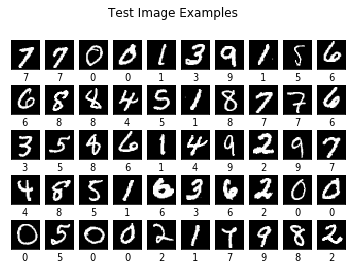

```python
X, y = fetch_mnist()

# rescale the data, use the traditional train/test split

X = X / 255.

X_train, X_test = X[:40000], X[40000:45000]
y_train, y_test = y[:40000], y[40000:45000]

### Display training images

for i in range(50):
    l1_plot = plt.subplot(5, 10, i + 1)
    l1_plot.imshow(255 * X_test[i].reshape(28, 28), interpolation='nearest',
                   cmap=plt.cm.gray)
    l1_plot.set_xticks(())
    l1_plot.set_yticks(())
    l1_plot.set_xlabel('%i' % int(y_test[i]))
plt.suptitle('Test Image Examples')
plt.show()

scaler = StandardScaler()
X_train = scaler.fit_transform(X_train)
X_test = scaler.transform(X_test)
```

# Linear SVM - MNIST

```python
from sklearn.svm import SVC

scaler = StandardScaler()
X_train = scaler.fit_transform(X_train)
X_test = scaler.transform(X_test)

start_time = time.time()
#Classifier Declaration
## Linear SVM
clf = SVC(kernel = 'linear', C = 1)
#Train the classifier
clf.fit(X_train, y_train)
train_time = time.time() - start_time
start_time = time.time()
print("Training time %.3f seconds" % train_time)
#Evaluate the result
score = clf.score(X_test,y_test)
test_time = time.time() - start_time
print("Test time MNIST %.3f seconds" % test_time)
print("Test score with Linear SVM for MNIST is: %.4f" % score)
```

```
Training time 479.832 seconds
Test time MNIST 70.508 seconds
Test score with Linear SVM for MNIST is: 0.9142
```

# Linear SVM - Own Dataset

```python
start_time = time.time()
#Evaluate the result
score = clf.score(X_own,y_own)
test_time = time.time() - start_time
print("Test time own dataset %.3f seconds" % test_time)
print("Test score with Linear SVM for own dataset is: %.4f" % score)
```

```
Test time own dataset 1.016 seconds
Test score with Linear SVM for own dataset is: 0.7167
```

# Cubic Polynomial - MNIST

```python
from sklearn.svm import SVC

start_time = time.time()
#Classifier Declaration
##Cubic Polynomial
clf = SVC(kernel = 'poly',degree = 3, C = 1, gamma = 'auto')
#Train the classifier
clf.fit(X_train, y_train)
train_time = time.time() - start_time
start_time = time.time()
print("Training time %.3f seconds" % train_time)
#Evaluate the result
score = clf.score(X_test,y_test)
test_time = time.time() - start_time
print("Test time %.3f seconds" % test_time)
print("Test score with Cubic Polynomial is: %.4f" % score)
```

```
Training time 721.913 seconds
Test time 70.452 seconds
Test score with Cubic Polynomial is: 0.9466
```

# Cubic Polynomial - Own Dataset

```python
start_time = time.time()
#Evaluate the result
score = clf.score(X_own,y_own)
test_time = time.time() - start_time
print("Test time own dataset %.3f seconds" % test_time)
print("Test score with Cubic Polynomial for own dataset is: %.4f" % score)
```

```
Test time own dataset 0.865 seconds
Test score with Cubic Polynomial for own dataset is: 0.7167
```

# Reload MNIST

```python
X, y = fetch_mnist()

# rescale the data, use the traditional train/test split

X = X / 255.

X_train, X_test = X[:20000], X[20000:22500]
y_train, y_test = y[:20000], y[20000:22500]

scaler = StandardScaler()
X_train = scaler.fit_transform(X_train)
X_test = scaler.transform(X_test)
```

# Radial Basis Function - MNIST (gamma 0.5)

```python
from sklearn.svm import SVC
start_time = time.time()
#Classifier Declaration
## Radial Basis Functions
clf = SVC(kernel = 'rbf', C = 1, gamma = 0.5)
#Train the classifier
clf.fit(X_train, y_train)
train_time = time.time() - start_time
start_time = time.time()
print("Training time %.3f seconds" % train_time)
#Evaluate the result
score = clf.score(X_test,y_test)
test_time = time.time() - start_time
print("Test time %.3f seconds" % test_time)
print("Test score with Radial Basis Functions is: %.4f" % score)
```

```
Training time 654.853 seconds
Test time 41.225 seconds
Test score with Radial Basis Functions is: 0.1120
```

# Radial Basis Function - Own Dataset (gamma 0.5)

```python
start_time = time.time()
#Evaluate the result
score = clf.score(X_own,y_own)
test_time = time.time() - start_time
print("Test time own dataset %.3f seconds" % test_time)
print("Test score with Radial Basis Functions for own dataset is: %.4f" % score)
```

```
Test time own dataset 1.013 seconds
Test score with Radial Basis Functions for own dataset is: 0.0833
```

# Radial Basis Function - MNIST (gamma 0.01)

```python
from sklearn.svm import SVC
start_time = time.time()
#Classifier Declaration
## Radial Basis Functions
clf = SVC(kernel = 'rbf', C = 1, gamma = 0.01)
#Train the classifier
clf.fit(X_train, y_train)
train_time = time.time() - start_time
start_time = time.time()
print("Training time %.3f seconds" % train_time)
#Evaluate the result
score = clf.score(X_test,y_test)
test_time = time.time() - start_time
print("Test time %.3f seconds" % test_time)
print("Test score with Radial Basis Functions is: %.4f" % score)
```

```
Training time 483.618 seconds
Test time 29.604 seconds
Test score with Radial Basis Functions is: 0.8120
```

# Radial Basis Function - Own Dataset (gamma 0.01)

```python
start_time = time.time()
#Evaluate the result
score = clf.score(X_own,y_own)
test_time = time.time() - start_time
print("Test time own dataset %.3f seconds" % test_time)
print("Test score with Radial Basis Functions for own dataset is: %.4f" % score)
```

```
Test time own dataset 0.717 seconds
Test score with Radial Basis Functions for own dataset is: 0.4167
```

# SVM Observations

Support vector machines create hyperplanes in high-dimentional feature space for classification. SVMs are generally faster because it uses kernel functions but it is at the cost of generalization error which increases with dimentionality. The effectiveness of SVM depends on the selection of kernel, the kernel's parameters, and soft margin parameter C.